# Vietnamese National University Entrance Exam in 2021 Analysis

Sang Kha

18/09/2021

# Table of Contents

- Introduction
- Ask
  - Guiding questions
  - Key tasks
  - Deliverable
- Prepare
  - Guiding questions
  - Key tasks
  - Deliverable
- Process
  - Code
    - Dependences
    - Data cleaning
  - Guiding questions
  - Key tasks
  - Deliverable
- Analyze
  - Code
    - Summary on subjects
    - Summary on group of subjects
    - Plot on subjects
    - Plot on group of subjects
  - Guiding questions
  - Key tasks
  - Deliverable
- Share
  - Guiding questions
  - Key tasks
  - Deliverable
- Act
  - Guiding questions
  - Key tasks
  - Deliverable
- Conclusion

# Introduction

This is the final project of Google Data Analytics Capstone - Case Study 3. The full document to the case study can be found in the [Google Data Analytics Capstone: Complete a Case Study](https://www.coursera.org/learn/google-data-analytics-capstone) course.

This is different from all the other cases in this course, as it gives you the opportunity to choose a business question that is of particular interest to you. As a result, finding datasets and conducting analysis will be more complex and will require you to make many decisions on your own.

In this project, I will use test result database provided by Department of Education and Training. Also, I will use data crawling tool (Python) to get the CSV file from raw html format so that R can import the data and begin analysing.

For this project these steps will be followed to ensure its completion:

- It will follow the steps of the data analysis process: Ask, prepare, process, analyze, share, and act.
- Each step will follow its own roadmap with:
  - Code, if needed on the step.
  - Guiding questions, with answers.
  - Key tasks, as a checklist.
  - Deliverable, as a checklist.

# Ask

### Guiding questions

- **What topic are you exploring?**

In this project, I am exploring the grades of Vietnamese students in the their National University Entrance Exam.

- **What is the problem you are trying to solve?**

Students will have more information to decide which school and career to enroll in base on their score compared to the analysed result.

- **What metrics will you use to measure your data to achieve your objective?**

I will use visualization of this data from multiple internet sources to measure my accuracy.

### Key tasks

- Identify the business task
- Consider key stakeholders

### Deliverable

- A clear statement of the business task

# Prepare

### Guiding questions

- **Where is your data located?**

The project will use the data provided by [this public dataset](https://vietnamnet.vn/vn/giao-duc/tra-cuu-diem-thi-thpt/).

- **How is the data organized?**

At first, this website allows us to find data of each candidate using their ID number. By using some Python data crawling skills, we can extract data of many candidates and store them into one CSV file.

- **Are there issues with bias or credibility in this data?**

There will be no issue as this is the data publish by Department of Education.

- **How are you addressing licensing, privacy, security, and accessibility?**

Candidate’s personal information will not be included, as the analysis do not use any of person’s ID number or name. Just their score will be recorded, but anonymously.

- **How did you verify the data’s integrity?**

I tested my data crawling algorithm many times before hand to make sure the data collected is sufficient and relevant.

- **How does it help you answer your question?**

Using this accurate dataset, I will be able to analyse and visualize the scores achieve by many candidates, therefore accomplish my initial goal.

### Key tasks

- Download data and store it appropriately.
- Identify how it’s organized.
- Sort and filter the data.
- Determine the credibility of the data.

### Deliverable

- A description of all data sources used

The main data source last updated time is 18/09/2021.

# Process

### Guiding questions

- **What tools are you choosing and why?**

I used Python with some special libraries (pandas, request,..) for webscraping the data from website and export to a CSV file.

Then I processed the data using R to clean it up and ensure data integrity.

- **Have you ensured your data’s integrity?**

Yes, the data is consistent throughout the columns.

- **What steps have you taken to ensure that your data is clean?**

- **How can you verify that your data is clean and ready to analyze?**

It can be verified by this notebook.

- **Have you documented your cleaning process so you can review and share those results?**

Yes, it’s all documented in this R notebook.

### Code

#### Dependencies

The main dependency for the project will be tidyverse.

```r
library(tidyverse)
```

```r
library(dplyr)
library(ggplot2)
```

#### Import the CSV file

```r
score_data<-read.csv("hcm.csv")
head(score_data)
```

```
##   X TOAN  VAN   LY HOA SINH   SU  DIA GDCD NGOAINGU CODE_NGOAINGU groupCode
## 1 0  8.2 7.00 8.00 8.5 7.75   NA   NA   NA      8.2            N1         2
## 2 1  8.8 7.00   NA  NA   NA 7.75 8.00 9.00      9.8            N1         2
## 3 2  7.8 6.50   NA  NA   NA 7.75 7.25 9.25      9.2            N6         2
## 4 3  6.6 7.00   NA  NA   NA 6.00 7.50 9.25      9.6            N1         2
## 5 4  8.0 6.75 5.75 8.0 7.25   NA   NA   NA      8.6            N1         2
## 6 5  7.8 6.50   NA  NA   NA 6.75 6.50 8.25      8.8            N1         2
##   HKTN HKXH  A00  B00  C00  D01  A01
## 1 24.3   NA 24.7 24.5   NA 23.4 24.4
## 2   NA 24.8   NA   NA 22.8 25.6   NA
## 3   NA 24.3   NA   NA 21.5 23.5   NA
## 4   NA 22.8   NA   NA 20.5 23.2   NA
## 5 21.0   NA 21.8 23.3   NA 23.4 22.4
## 6   NA 21.5   NA   NA 19.8 23.1   NA
```

#### Data cleaning

```r
score_data$X <- NULL
score_data$groupCode <-NULL
```

### Key tasks

- Check the data for errors.
- Choose your tools.
- Transform the data so you can work with it effectively
- Document the cleaning process.

### Deliverable

- Documentation of any cleaning or manipulation of data

# Analyze

### Summary by subjects

```r
cols<-c("TOAN","VAN","LY","HOA","SINH","SU","DIA","GDCD")
nn1<-filter(score_data,CODE_NGOAINGU=="N1")
nn6<-filter(score_data,CODE_NGOAINGU=="N6")
colnames(nn1)[colnames(nn1)=="NGOAINGU"]<-"NN1"
colnames(nn6)[colnames(nn6)=="NGOAINGU"]<-"NN6"

summary(score_data[cols])
```

```
##       TOAN            VAN              LY             HOA
##  Min.   :3.000   Min.   :1.750   Min.   :3.000   Min.   :2.750
##  1st Qu.:7.400   1st Qu.:6.250   1st Qu.:5.750   1st Qu.:5.750
##  Median :7.800   Median :6.750   Median :6.750   Median :6.750
##  Mean   :7.762   Mean   :6.746   Mean   :6.574   Mean   :6.675
##  3rd Qu.:8.400   3rd Qu.:7.500   3rd Qu.:7.500   3rd Qu.:7.750
##  Max.   :9.800   Max.   :9.000   Max.   :9.000   Max.   :9.000
##                                  NA's   :281     NA's   :281
##       SINH             SU            DIA             GDCD
##  Min.   :2.000   Min.   :2.50   Min.   :3.500   Min.   : 4.750
##  1st Qu.:4.750   1st Qu.:5.00   1st Qu.:6.750   1st Qu.: 8.250
##  Median :5.500   Median :6.00   Median :7.500   Median : 8.750
##  Mean   :5.577   Mean   :6.06   Mean   :7.319   Mean   : 8.619
##  3rd Qu.:6.250   3rd Qu.:7.25   3rd Qu.:8.000   3rd Qu.: 9.250
##  Max.   :9.750   Max.   :9.25   Max.   :9.750   Max.   :10.000
##  NA's   :281     NA's   :679    NA's   :679     NA's   :679
```

```r
summary(nn1["NN1"])
```

```
##       NN1
##  Min.   : 2.400
##  1st Qu.: 8.000
##  Median : 8.800
##  Mean   : 8.468
##  3rd Qu.: 9.200
##  Max.   :10.000
```

```r
summary(nn6["NN6"])
```

```
##       NN6
##  Min.   :5.60
##  1st Qu.:8.10
##  Median :8.80
##  Mean   :8.40
##  3rd Qu.:9.35
##  Max.   :9.60
```

### Summary by Groups

```r
cols_group<-c("HKTN","HKXH","A00","B00","C00","D01","A01")
summary(score_data[cols_group])
```

```
##       HKTN            HKXH            A00             B00
##  Min.   :10.50   Min.   :11.50   Min.   :13.00   Min.   :10.00
##  1st Qu.:17.30   1st Qu.:20.30   1st Qu.:19.75   1st Qu.:18.60
##  Median :19.00   Median :22.30   Median :21.60   Median :20.20
##  Mean   :18.85   Mean   :22.02   Mean   :21.19   Mean   :20.19
##  3rd Qu.:20.50   3rd Qu.:23.80   3rd Qu.:22.90   3rd Qu.:21.80
##  Max.   :25.30   Max.   :27.30   Max.   :26.80   Max.   :26.90
##  NA's   :281     NA's   :679     NA's   :281     NA's   :281
##       C00             D01             A01
##  Min.   : 8.00   Min.   :11.40   Min.   :12.3
##  1st Qu.:19.00   1st Qu.:22.00   1st Qu.:21.7
##  Median :20.80   Median :23.20   Median :23.0
##  Mean   :20.57   Mean   :22.98   Mean   :22.9
##  3rd Qu.:22.30   3rd Qu.:24.20   3rd Qu.:24.4
##  Max.   :26.00   Max.   :26.90   Max.   :27.2
##  NA's   :679     NA's   :22      NA's   :300
```

### Plot by subjects

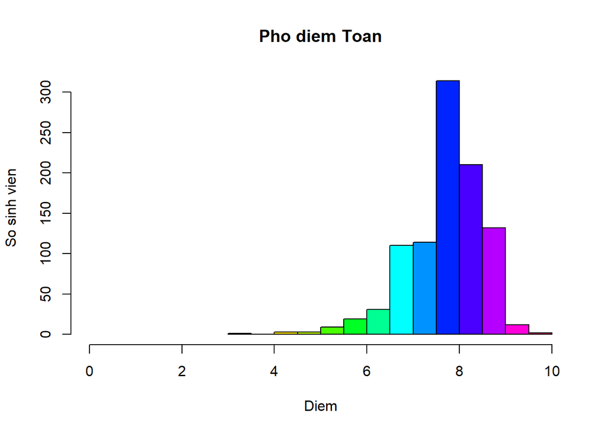

```r
hist(score_data$TOAN,main="Pho diem Toan",xlab="Diem",ylab="So sinh vien",
     xlim=c(0,10),col=rainbow(14))
```

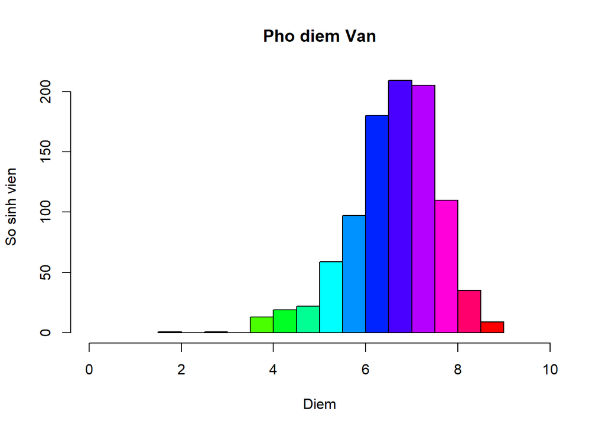

```r
hist(score_data$VAN,main="Pho diem Van",xlab="Diem",ylab="So sinh vien",
     xlim=c(0,10),col=rainbow(14))
```

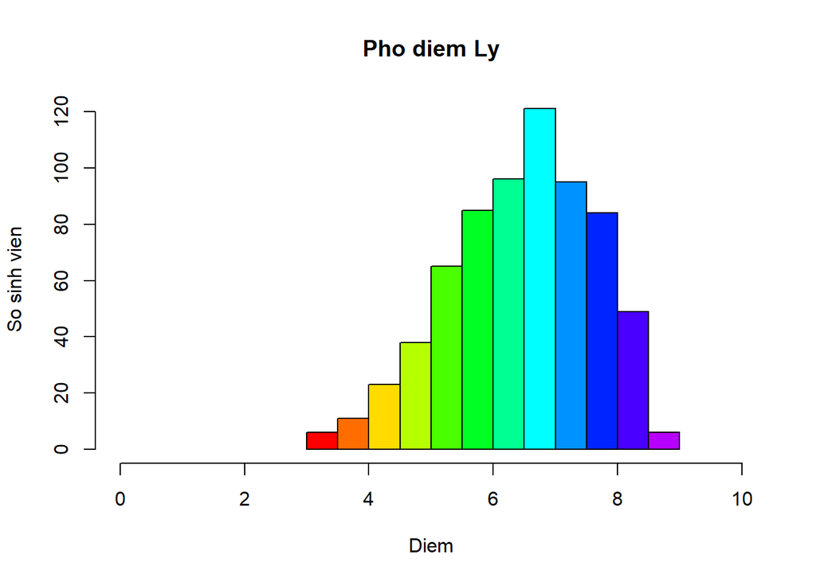

```r
hist(score_data$LY,main="Pho diem Ly",xlab="Diem",ylab="So sinh vien",
     xlim=c(0,10),col=rainbow(14))
```

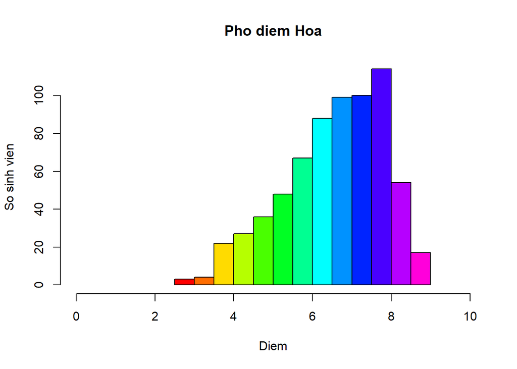

```r
hist(score_data$HOA,main="Pho diem Hoa",xlab="Diem",ylab="So sinh vien",
     xlim=c(0,10),col=rainbow(14))
```

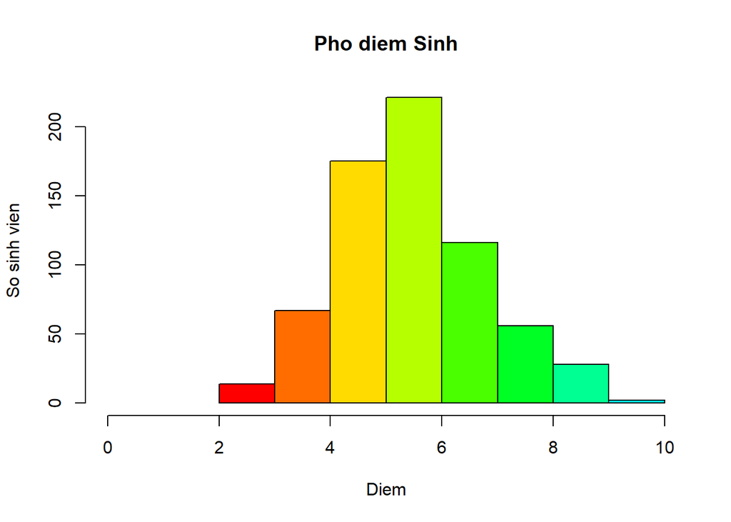

```r
hist(score_data$SINH,main="Pho diem Sinh",xlab="Diem",ylab="So sinh vien",
     xlim=c(0,10),col=rainbow(14))
```

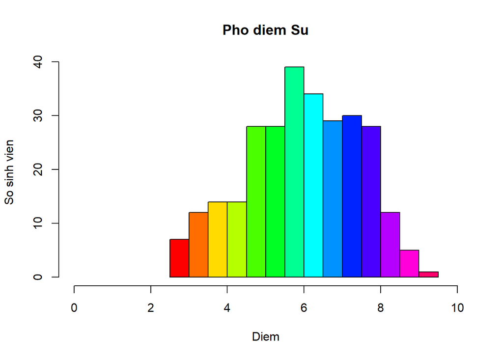

```r
hist(score_data$SU,main="Pho diem Su",xlab="Diem",ylab="So sinh vien",
     xlim=c(0,10),col=rainbow(14))
```

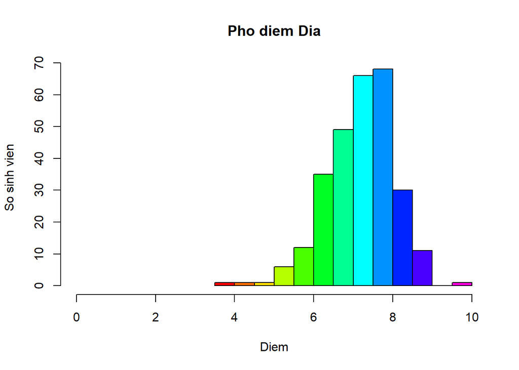

```r
hist(score_data$DIA,main="Pho diem Dia",xlab="Diem",ylab="So sinh vien",
     xlim=c(0,10),col=rainbow(14))
```

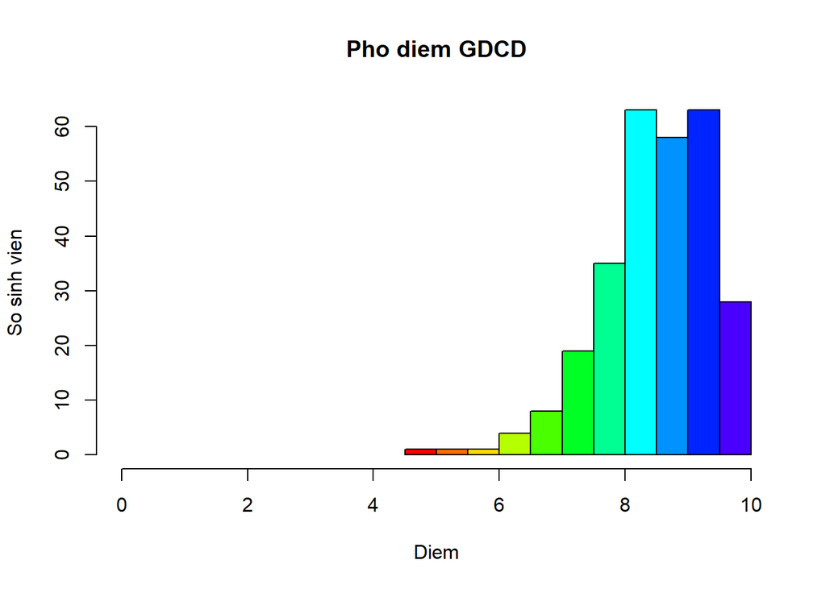

```r
hist(score_data$GDCD,main="Pho diem GDCD",xlab="Diem",ylab="So sinh vien",
     xlim=c(0,10),col=rainbow(14))
```

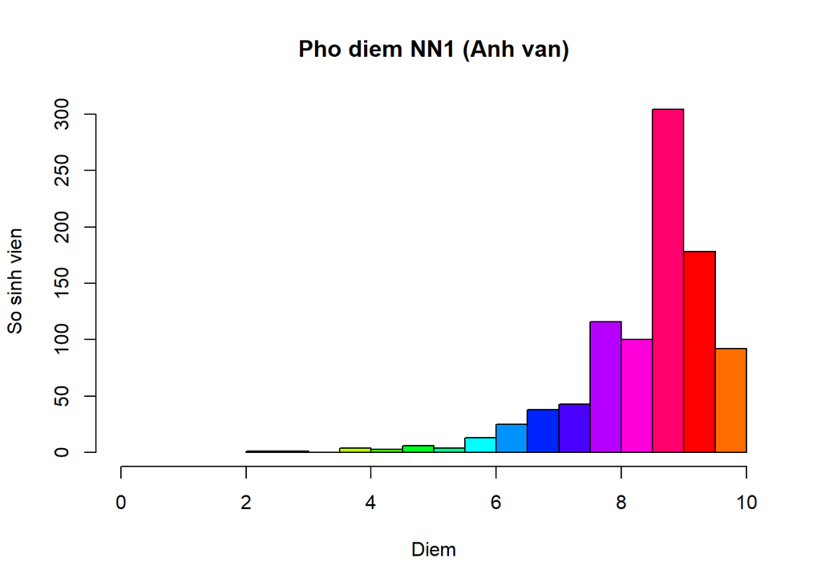

```r
hist(nn1$NN1,main="Pho diem NN1 (Anh van)",xlab="Diem",ylab="So sinh vien",
     xlim=c(0,10),col=rainbow(14))
```

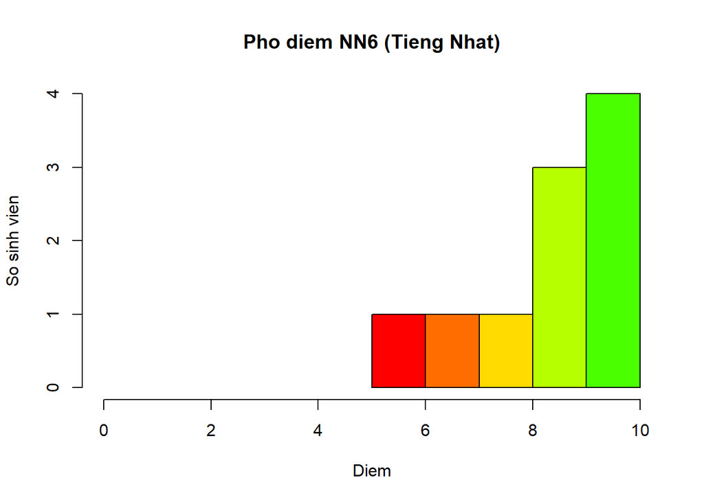

```r
hist(nn6$NN6,main="Pho diem NN6 (Tieng Nhat)",xlab="Diem",ylab="So sinh vien",
     xlim=c(0,10),col=rainbow(14))
```

### Plot by Groups

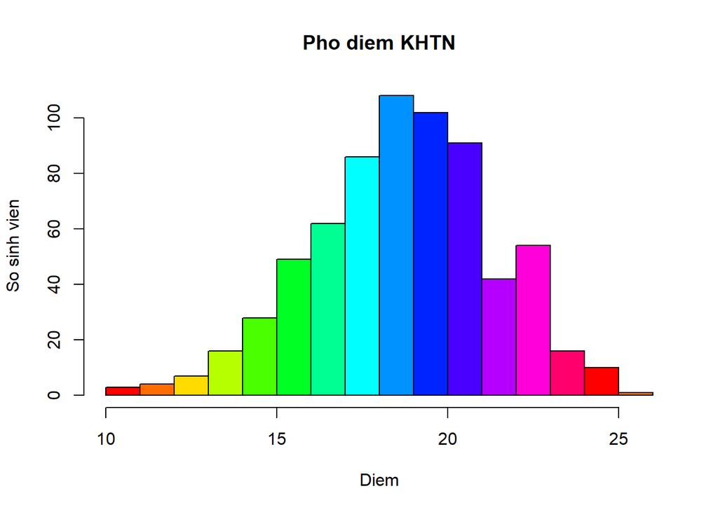

```r
hist(score_data$HKTN,main="Pho diem KHTN",xlab="Diem",ylab="So sinh vien",col=rainbow(14))
```

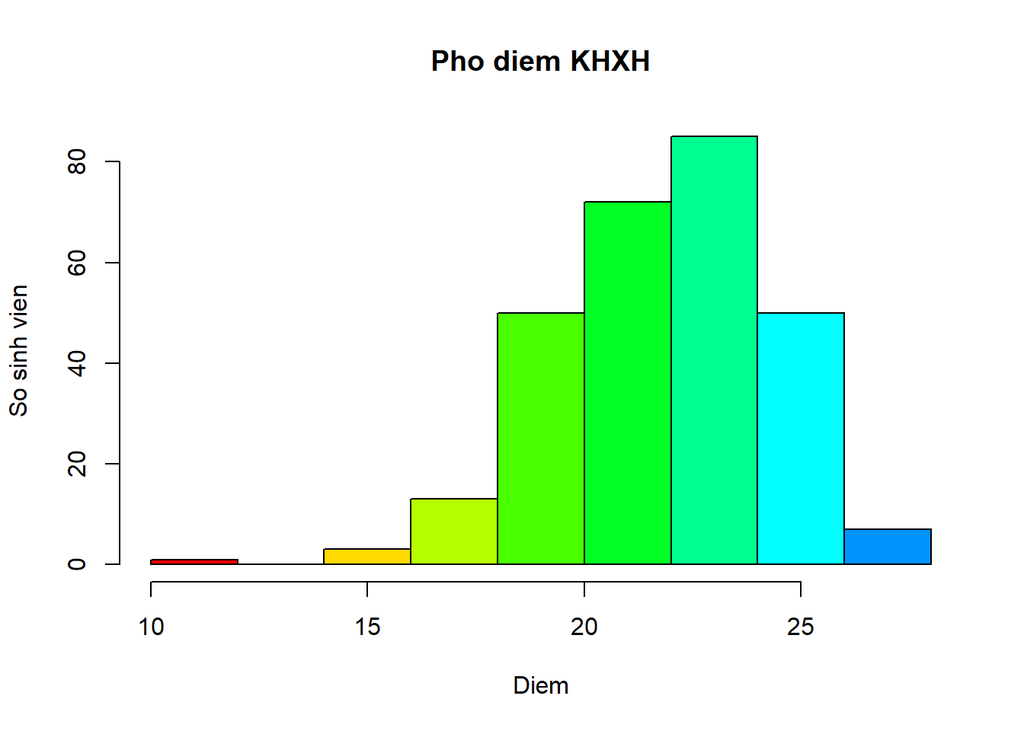

```r
hist(score_data$HKXH,main="Pho diem KHXH",xlab="Diem",ylab="So sinh vien",col=rainbow(14))
```

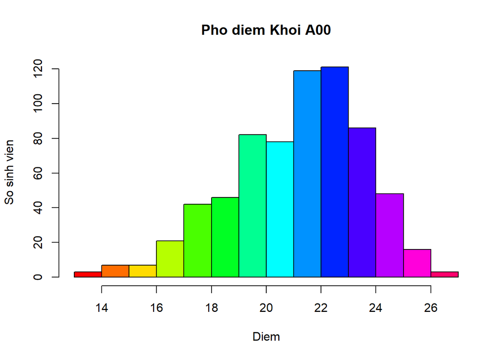

```r
hist(score_data$A00,main="Pho diem Khoi A00",xlab="Diem",ylab="So sinh vien",col=rainbow(14))
```

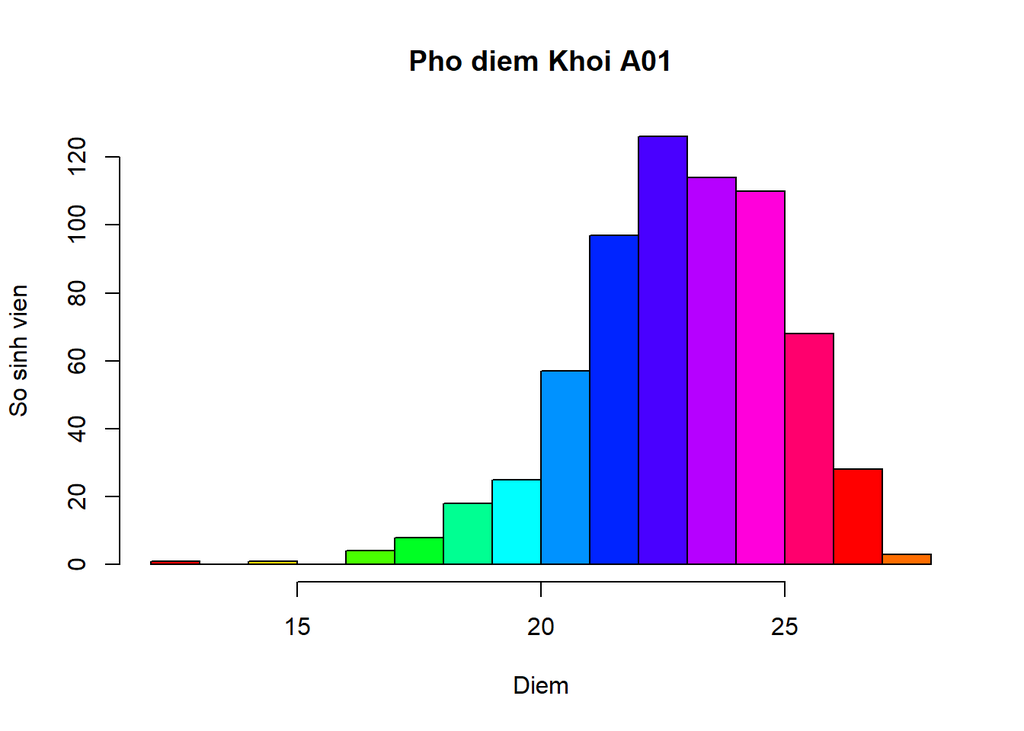

```r
hist(score_data$A01,main="Pho diem Khoi A01",xlab="Diem",ylab="So sinh vien",col=rainbow(14))
```

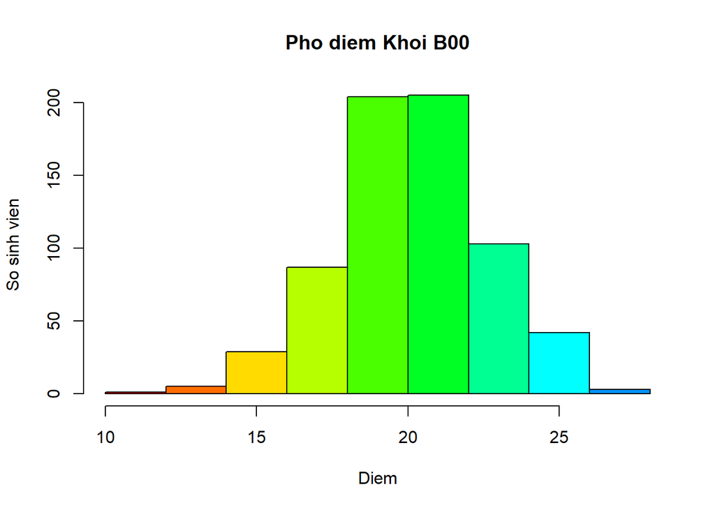

```r
hist(score_data$B00,main="Pho diem Khoi B00",xlab="Diem",ylab="So sinh vien",col=rainbow(14))
```

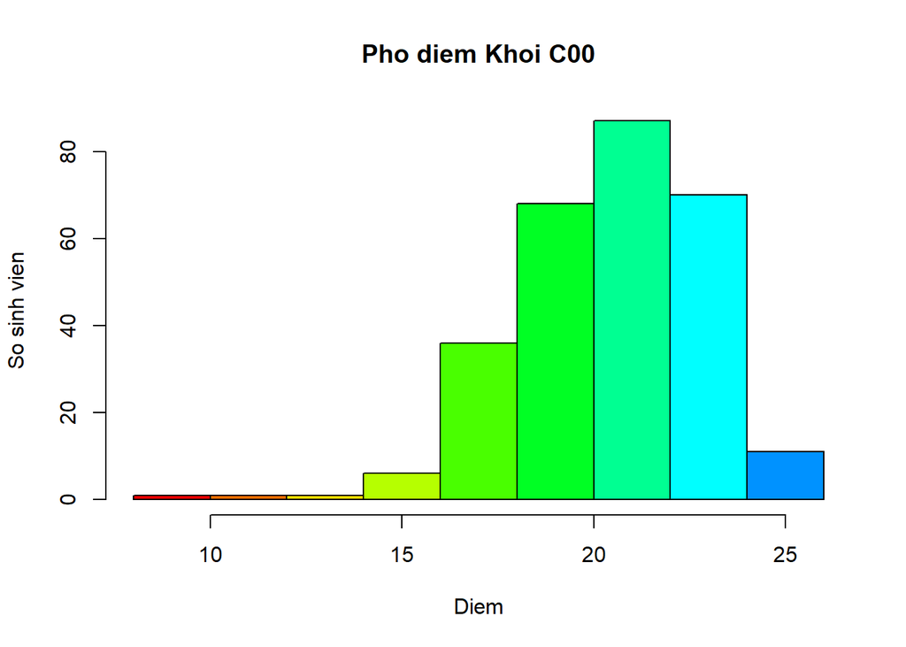

```r
hist(score_data$C00,main="Pho diem Khoi C00",xlab="Diem",ylab="So sinh vien",col=rainbow(14))
```

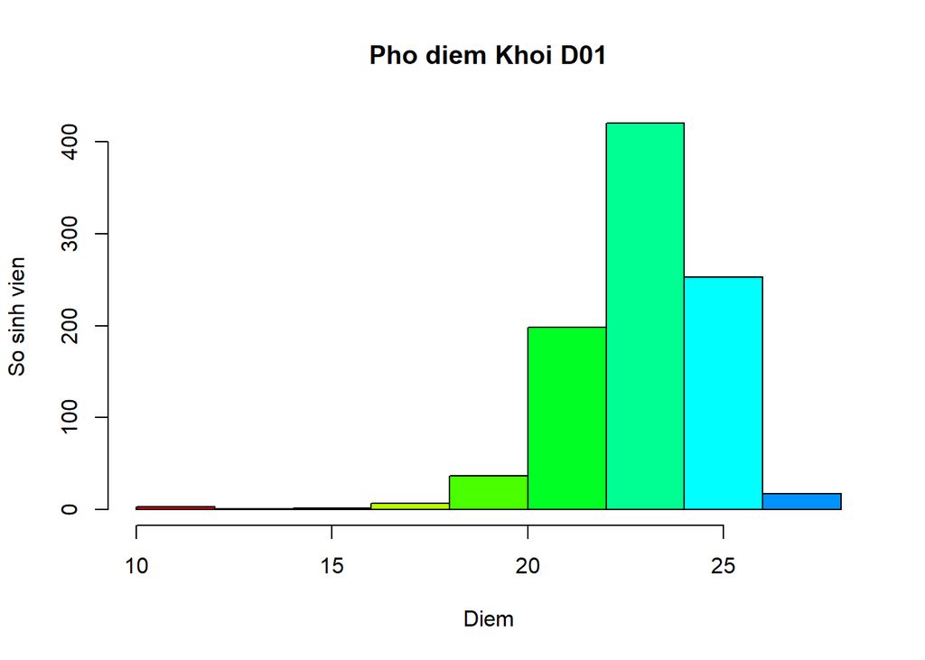

```r
hist(score_data$D01,main="Pho diem Khoi D01",xlab="Diem",ylab="So sinh vien",col=rainbow(14))
```

### Guiding questions

- **How should you organize your data to perform analysis on it?**

The data has been organized into a single CSV concatenating all the files from the dataset.

- **Has your data been properly formatted?**

Yes, all the columns have their correct data type.

### Key tasks

- Aggregate your data so it’s useful and accessible.
- Organize and format your data.
- Perform calculations.
- Identify trends and relationships.

### Deliverable

- A summary of your analysis

# Share

Now that you have performed your analysis and gained some insights into your data, create visualizations to share your findings.

You will be presenting to your client and other stakeholders, so visuals should be sophisticated and polished in order to effectively communicate your insights.

### Guiding questions

- **What story does your data tell?**

My data tells the exam result distribution in National University Entrance Exam 2021

- **How do your findings relate to your original question?**

My findings in fact are still at a decent scale as I just get data of 1000 candidate in Ho Chi Minh City as a sample to analyse the data. However, it stills represent some main features of the big picture.

- **Who is your audience? What is the best way to communicate with them?**

My audience will be teachers, parents or students who are concerning about choosing the right university base on their exam result.

- **Can data visualization help you share your findings?**

Yes, the main core of the finds is through data visualization. They will figure out where they are in the middle of scores collected, therefore make better decision.

- **Is your presentation accessible to your audience?**

Yes, the plots were made using vibrant colors, and corresponding labels.

### Key tasks

- Determine the best way to share your findings.
- Create effective data visualizations.
- Present your findings.
- Ensure your work is accessible.

### Deliverable

- Supporting visualizations and key findings

# Act

Now that you have finished creating your visualizations, act on your findings. Organize the deliverables you created, including your top high-level insights based on your analysis.

### Guiding questions

- **What is your final conclusion based on your analysis?**

My analysis is just a reference for who want to have a quick look at students’ literacy level in VietNam, 2021. The main reason behind this analysis is to show my data analysis skill that I learnt through Google Data Analytics Courses.

- **Is there additional data you could use to expand on your findings?**

Maybe in the future, I will expand the data to investigate all students in VietNam, but that will take a lot of time.

### Key tasks

- Create your portfolio.
- Add your case study.
- Practice presenting your case study to a friend or family member.

### Deliverable

- Your top high-level insights based on your analysis
- Based on what you discover, a list of additional deliverables you think would be helpful to include for further exploration